# Лабораторная работа №12

Операционные системы

Верниковская Е. А., НПИбд-01-23

Российский университет дружбы народов, Москва, Россия

25 апреля 2024

# Вводная часть

## Цель работы

Изучить основы программирования в оболочке ОС UNIX/Linux, а также научиться писать небольшие командные файлы.

## Задание

1. Написать скрипт, который при запуске будет делать резервную копию самого себя (то есть файла, в котором содержится его исходный код) в другую директорию backup в вашем домашнем каталоге. При этом файл должен архивироваться одним из архиваторов на выбор zip, bzip2 или tar. Способ использования команд архивации необходимо узнать, изучив справку.
2. Написать пример командного файла, обрабатывающего любое произвольное число аргументов командной строки, в том числе превышающее десять. Например, скрипт может последовательно распечатывать значения всех переданных аргументов.

## Задание

3. Написать командный файл — аналог команды ls (без использования самой этой команды и команды dir). Требуется, чтобы он выдавал информацию о нужном каталоге и выводил информацию о возможностях доступа к файлам этого каталога.
4. Написать командный файл, который получает в качестве аргумента командной строки формат файла (.txt, .doc, .jpg, .pdf и т.д.) и вычисляет количество таких файлов в указанной директории также передаётся в виде аргумента командной строки.

# Выполнение лабораторной работы

## Задание №1

Создаю файл для первого задания с расширением sh и делаю его исполняемым (рис. 1)

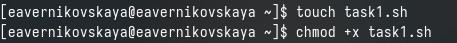

Создание файла task1.sh и добавление прав на исполнение

## Задание №1

Открываю файл task1.sh в текстовом редакторе gedit и пишу скрипт, который при запуске будет делать резервную копию самого себя (то есть файла, в котором содержится его исходный код) в другую директорию backup в нашем домашнем каталоге. При этом файл должен архивироваться одним из архиваторов на выбор zip, bzip2 или tar (рис. 2), (рис. 3)

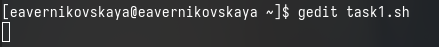

Открытие файла task1.sh

## Задание №1

[figure not shown]

Написанный скрипт для task1.sh

## Задание №1

Далее запускаю файл с помощью bash и проверяю работу скрипта (рис. 4), (рис. 5), (рис. 6)

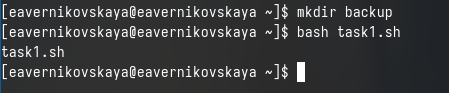

Проверка работы скрипта task1.sh (1)

## Задание №1

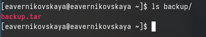

Проверка работы скрипта task1.sh (2)

## Задание №1

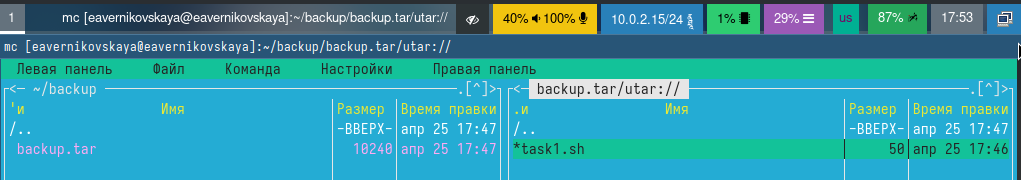

Проверка работы скрипта task1.sh (3)

## Задание №2

Создаю файл для второго задания с расширением sh и делаю его исполняемым (рис. 7)

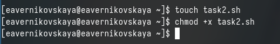

Создание файла task2.sh и добавление прав на исполнение

## Задание №2

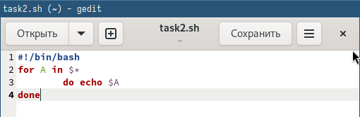

Написанный скрипт для task2.sh

## Задание №2

Далее запускаю файл с помощью bash и проверяю его работу (рис. 10)

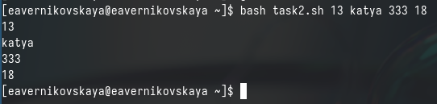

Проверка работы скрипта task2.sh

## Задание №3

Создаю файл для третьего задания с расширением sh и делаю его исполняемым (рис. 11)

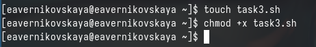

Создание файла task3.sh и добавление прав на исполнение

## Задание №3

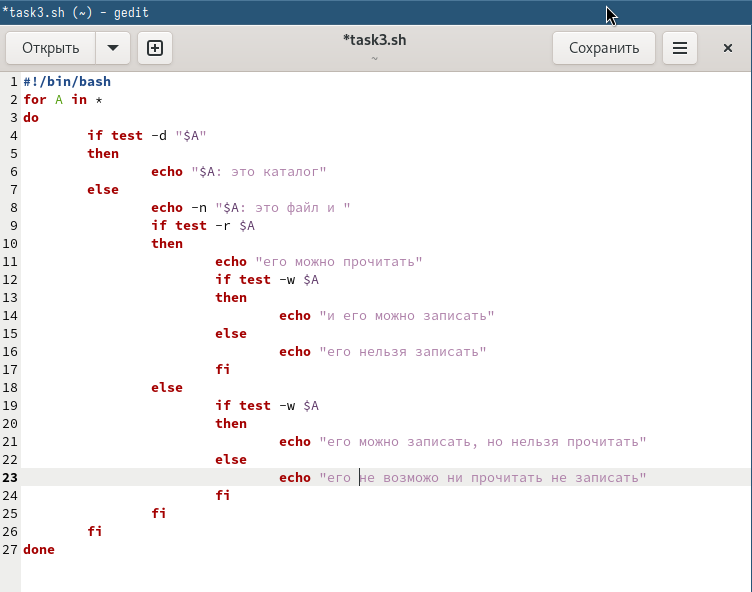

Написанный скрипт для task3.sh

## Задание №3

Далее запускаю файл с помощью bash и проверяю его работу (рис. 14)

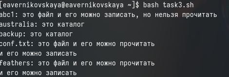

Проверка работы скрипта task3.sh

## Задание №4

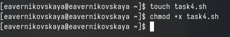

Создание файла task4.sh и добавление прав на исполнение

## Задание №4

[figure not shown]

Написанный скрипт для task4.sh

## Задание №4

Далее запускаю файл с помощью bash и проверяю его работу (рис. 18), (рис. 19)

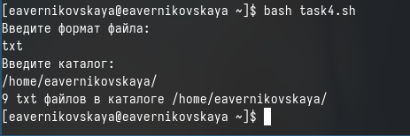

Проверка работы скрипта task4.sh (1)

## Задание №4

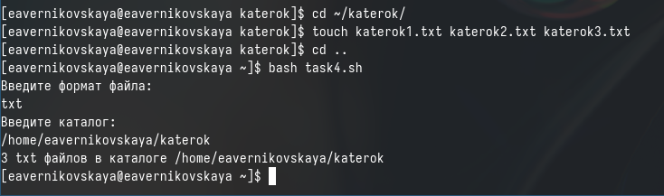

Проверка работы скрипта task4.sh (2)

# Подведение итогов

## Выводы

В ходе выполнения лабораторной работы мы изучили основы программирования в оболочке ОС UNIX/Linux, а также научились писать небольшие командные файлы.

## Список литературы

Не пользовалась сайтами.